# PA1_template

# Are there differences in activity patterns between weekdays and weekends?

The weekdays() function may be of some help here. Use the dataset with the filled-in missing values for this part. Create a new factor variable in the dataset with two levels - “weekday” and “weekend” indicating whether a given date is a weekday or weekend day. Make a panel plot containing a time series plot (i.e. type = “l”) of the 5-minute interval (x-axis) and the average number of steps taken, averaged across all weekday days or weekend days (y-axis). See the README file in the GitHub repository to see an example of what this plot should look like using simulated data.

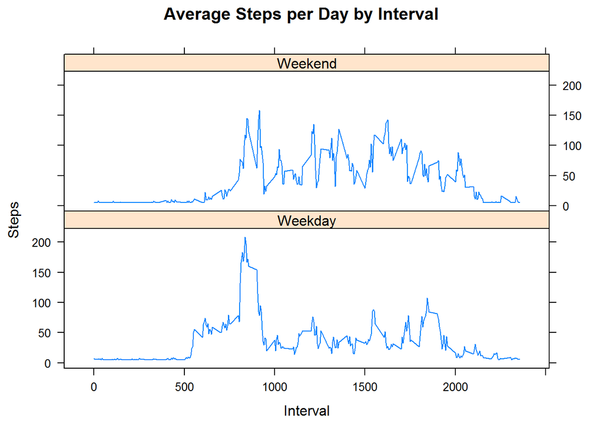

```r
weekdays <- c("Monday", "Tuesday", "Wednesday", "Thursday", "Friday")
Step_Data_Imputed$Weekday = as.factor(ifelse(is.element(weekdays(as.Date(Step_Data_Imputed$date)),weekdays), "Weekday", "Weekend"))

Steps_Interval_Imputed <- aggregate(steps ~ interval + Weekday, Step_Data_Imputed, mean)

xyplot(Steps_Interval_Imputed$steps ~ Steps_Interval_Imputed$interval|Steps_Interval_Imputed$Weekday, main="Average Steps per Day by Interval",xlab="Interval", ylab="Steps",layout=c(1,2), type="l")
```